# ModernDive: Statistical Inference via Data Science

Wed May 23rd, 2018

## Pop quiz!

Sampling from a bowl of red and white balls!

## About me

- PhD trained statistician
- Worked at Google in AdWords Division
- Small colleges: Reed, Middlebury, Amherst, and now Smith Colleges
- Awash in "statistics vs data science" debates

## Awash in Venn Diagrams…

| Drew Conway | Drew Conway 2.0 |
| --- | --- |

## Awash in quotes…

Some more problematic than others:

- A data scientist is someone who is better at statistics than any software engineer and better at software engineering than any statistician.
- A data scientist is a statistician who lives in San Francisco
- [A data scientist is a statistician who is wearing a bow tie.](https://twitter.com/francescadomin8/status/906608168733511680)
- From my time at Google: An engineer knows what an average is, but an analyst knows what a standard deviation is

## rudeboybert says

What can statistics bring to the data science table? Among other things, how about?

> **A statistician is a data scientist who understands what a standard error is.**

## ModernDive

- Open source electronic textbook available at [moderndive.com](http://moderndive.com/)
- Development version at [moderndive.netlify.com](http://moderndive.netlify.com/) (source of today's examples)
- RStudio [`bookdown`](https://bookdown.org/yihui/bookdown/) package source code on GitHub at github.com/moderndive/
- No programming background assumed

## A few pedagogical principles

1. Have intro students ["play the whole game"](http://a.co/50CpHGX)
2. Use data science, not probability/mathematical formulas, to motivate statistical inference
3. Coding as a basic skill

## Principle 1: "Play the whole game"

In the context of statistics/data analysis, by "play the whole game" we mean Wickham's data/science pipeline:

[figure not shown]

## Tee-ball

Think how children learn "tee-ball" and play a simplified version of the "whole game" first…

[figure not shown]

## Softball & baseball

… and then eventually graduate to softball/baseball.

[figure not shown]

## Example "whole game"

- Load the [Seattle house prices dataset](https://www.kaggle.com/harlfoxem/housesalesprediction) from Kaggle saved in `moderndive::house_prices`
- Model \(y\) the sale `price` of house as a function of two explanatory/predictor variables:
  1. \(x_1\): size (`sqft_living` square feet)
  2. \(x_2\): `condition` (catgorical w/ 1 = lowest, 5 = best)
- Communicate the results to a realtor

### 1. Load packages and data

Load subset of variables:

```r
library(ggplot2)
library(dplyr)
library(moderndive)
library(patchwork)
house_prices %>%
  select(id, date, price, sqft_living, condition) %>%
  head()
```

```
## # A tibble: 6 x 5
##   id         date                  price sqft_living condition
##   <chr>      <dttm>                <dbl>       <int> <fct>
## 1 7129300520 2014-10-13 00:00:00  221900        1180 3
## 2 6414100192 2014-12-09 00:00:00  538000        2570 3
## 3 5631500400 2015-02-25 00:00:00  180000         770 3
## 4 2487200875 2014-12-09 00:00:00  604000        1960 5
## 5 1954400510 2015-02-18 00:00:00  510000        1680 3
## 6 7237550310 2014-05-12 00:00:00 1225000        5420 3
```

### 2. Exploratory data analysis

Variables `price` and `sqft_living` are right-skewed:

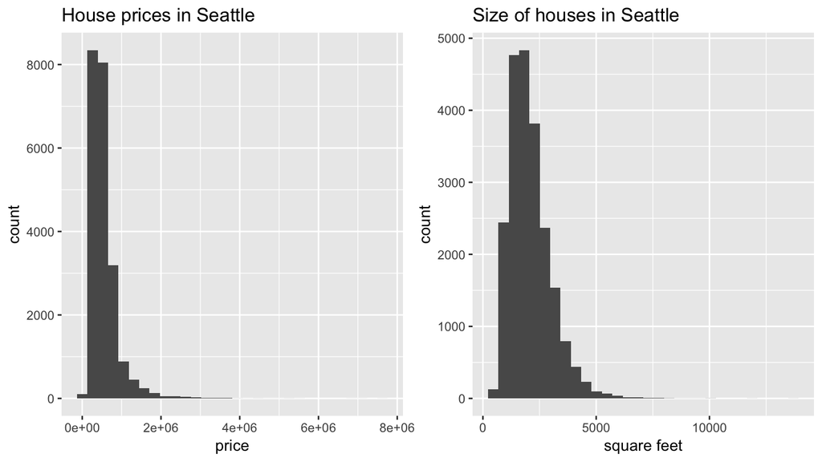

```r
p1 <- ggplot(house_prices, aes(x = price)) +
  geom_histogram() +
  labs(x = "price", title = "House prices in Seattle")
p2 <- ggplot(house_prices, aes(x = sqft_living)) +
  geom_histogram() +
  labs(x = "square feet", title = "Size of houses in Seattle")
p1 + p2
```

Apply a log base 10 tranformation:

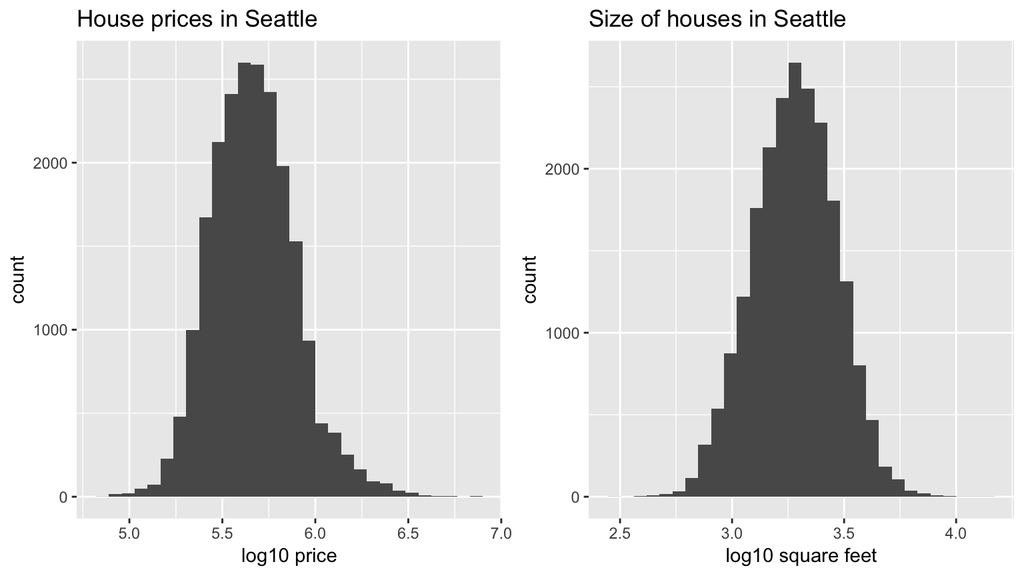

```r
house_prices <- house_prices %>%
  mutate(
    log10_price = log10(price),
    log10_sqft_living = log10(sqft_living)
    )

p1 <- ggplot(house_prices, aes(x = log10_price)) +
  geom_histogram() +
  labs(x = "log10 price", title = "House prices in Seattle")
p2 <- ggplot(house_prices, aes(x = log10_sqft_living)) +
  geom_histogram() +
  labs(x = "log10 square feet", title = "Size of houses in Seattle")
p1 + p2
```

### 3. Eyeball the relationship

Visualize the relationship between the variables using facets…

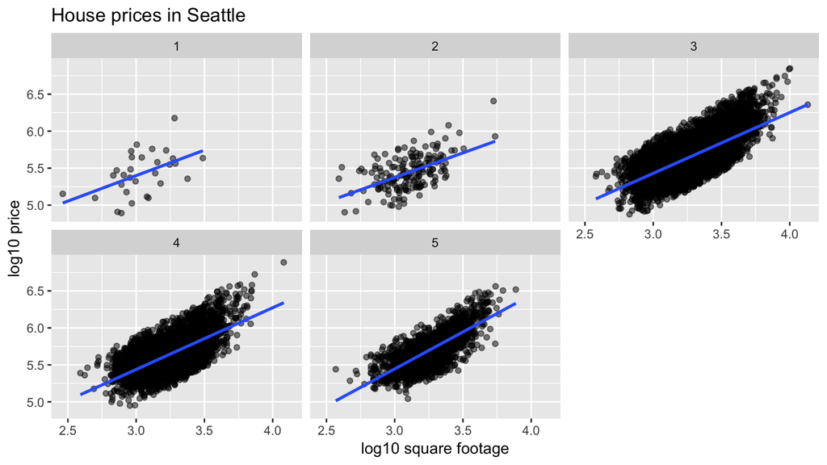

```r
ggplot(house_prices, aes(x = log10_sqft_living, y = log10_price)) +
  geom_point(alpha = 0.5) +
  labs(y = "log10 price", x = "log10 square footage", title = "House prices in Seattle") +
  geom_smooth(method = "lm", se = FALSE) +
  facet_wrap(~condition)
```

… or colors

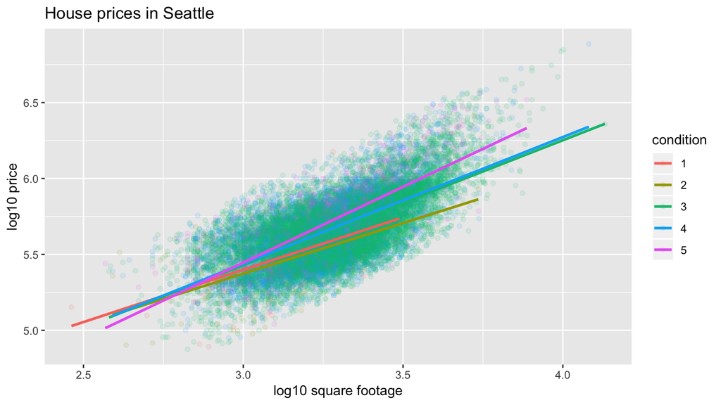

```r
ggplot(house_prices, aes(x = log10_sqft_living, y = log10_price, col = condition)) +
  geom_point(alpha = 0.1) +
  labs(y = "log10 price", x = "log10 square footage", title = "House prices in Seattle") +
  geom_smooth(method = "lm", se = FALSE)
```

### 4. Quantify the relationship

- Fit an interaction model which allows for a unique regression line for each `condition` value
- Output the regression table **along with confidence intervals, not just the p-values**.

```r
model_price <- lm(log10_price ~ log10_sqft_living * condition, data = house_prices)
get_regression_table(model_price)
```

```
## # A tibble: 10 x 7
##    term            estimate std_error statistic p_value conf_low conf_high
##    <chr>              <dbl>     <dbl>     <dbl>   <dbl>    <dbl>     <dbl>
##  1 intercept          3.33      0.451     7.38    0        2.45      4.22
##  2 log10_sqft_liv…    0.69      0.148     4.65    0        0.399     0.98
##  3 condition2         0.047     0.498     0.094   0.925   -0.93      1.02
##  4 condition3        -0.367     0.452    -0.812   0.417   -1.25      0.519
##  5 condition4        -0.398     0.453    -0.879   0.38    -1.29      0.49
##  6 condition5        -0.883     0.457    -1.93    0.053   -1.78      0.013
##  7 log10_sqft_liv…   -0.024     0.163    -0.148   0.882   -0.344     0.295
##  8 log10_sqft_liv…    0.133     0.148     0.893   0.372   -0.158     0.424
##  9 log10_sqft_liv…    0.146     0.149     0.979   0.328   -0.146     0.437
## 10 log10_sqft_liv…    0.31      0.15      2.07    0.039    0.016     0.604
```

## Objective

**End goal**: understand and interpret the inference for regression, which requires lot of skills/knowledge. For example:

1. What's the difference between R & RStudio? What's an R package?
2. How do effectively visualize data?
3. How can I clean data as it "exists in the wild"?
4. How do I model the relationship between variables?
5. What is the error/uncertainty of our results?

## Means to the end

1. Analogies: [R vs RStudio](http://moderndive.netlify.com/2-getting-started.html#what-are-r-and-rstudio) and [R packages](http://moderndive.netlify.com/2-getting-started.html#packages)
2. Visualization via `ggplot2`: [Grammar of Graphics](http://moderndive.netlify.com/3-viz.html#components-of-the-grammar) and limit scope to ["Five Named Graphs"](http://moderndive.netlify.com/3-viz.html#FiveNG)
3. `dplyr` ["Five Main Verbs"](http://moderndive.netlify.com/5-wrangling.html#five-main-verbs---the-5mv) for data wrangling/transformation
4. Descriptive regression modeling with emphasis on exploratory data analysis (See [Figure 7.4](http://moderndive.netlify.com/7-multiple-regression.html#model4EDA))
5. How do we teach ideas of representative sampling, sampling distributions, and standard errors? A work in progress…

## Principle 2: Inference via data science

> [@minebocek](https://twitter.com/minebocek?ref_src=twsrc%5Etfw) emphasizing that most students won't get excited about stats/data science via urn models/probability [#USCOTS2017](https://twitter.com/hashtag/USCOTS2017?src=hash&ref_src=twsrc%5Etfw) [pic.twitter.com/ume0kuvFYT](https://t.co/ume0kuvFYT)

> — Albert Y. Kim (@rudeboybert) [May 20, 2017](https://twitter.com/rudeboybert/status/865912673489346561?ref_src=twsrc%5Etfw)

## Simulations not probability/formulas

| More of this | Less of this |
| --- | --- |

## First: Tactile simulations

> Semi-annual tactile simulation of sampling to estimate proportion of balls in a bowl that are red (then construct sampling distribution). Went much cleaner this time with Red Solo Cups! [@tobykeith](https://twitter.com/tobykeith?ref_src=twsrc%5Etfw) [#letshaveaparty](https://twitter.com/hashtag/letshaveaparty?src=hash&ref_src=twsrc%5Etfw) [pic.twitter.com/6bqEdoFqvd](https://t.co/6bqEdoFqvd)

> — Albert Y. Kim (@rudeboybert) [March 22, 2018](https://twitter.com/rudeboybert/status/976850326874705920?ref_src=twsrc%5Etfw)

## Second: Virtual simulations

- Take a [virtual bowl](http://moderndive.netlify.com/8-sampling.html#virtual-sampling-from-bowl)
- Extract a virtual sample using a [virtual shovel](http://moderndive.netlify.com/8-sampling.html#virtually-using-shovel-once)
- Construct the sampling distribution by repeating the above 1000 times.
- Plot!

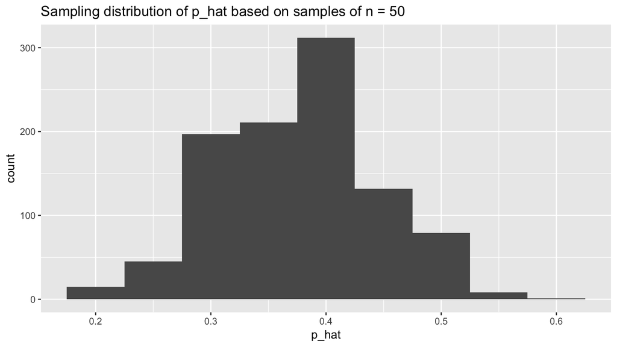

```r
library(dplyr)
library(ggplot2)
library(moderndive)

# Take 1000 virtual samples of size n = 50 from bowl
virtual_samples <- bowl %>%
  rep_sample_n(size = 50, reps = 1000)

# Compute 1000 simulated p-hats based on these 1000 virtual samples
virtual_p_hats <- virtual_samples %>%
  group_by(replicate) %>%
  summarize(p_hat = mean(color == "red"))

# Plot sampling distribution
ggplot(virtual_p_hats, aes(x = p_hat)) +
  geom_histogram(binwidth = 0.05) +
  labs(title = "Sampling distribution of p_hat based on samples of n = 50")
```

## Simulations

1. Need to do tactile simulations first; too many layers of abstraction otherwise
2. Draw link between tactile (actual bowl and shovel) and virtual (data frames and functions in R) then
3. To perform and deconstruct latter, students need to be equipped with a data science toolbox: data visualization and basic data wrangling.
4. [Example involving sample means](https://rudeboybert.github.io/STAT135/static/PS/PS10_solutions.html): Average year of minting of pennies using a virtual sack of \(N=800\) `pennies`

## State of affairs

- Beta version of above has been implemented in development version of ModernDive [Chapter 8: Sampling](https://moderndive.github.io/moderndive_book/8-sampling.html)
- **Under construction**: Chapters 9 thru 11 on confidence intervals, hypothesis testing, and inference for regression
- Pending developments on `infer` package https://infer.netlify.com/

## infer package for tidy statistical inference

[figure not shown]

- Confidence intervals: [image](https://ismayc.github.io/talks/ness-infer/img/infer_ci.jpg)
- Hypothesis tests: [image](https://ismayc.github.io/talks/ness-infer/slide_deck.html#119)
- Allan Downey idea of ["There is only one test"](https://ismayc.github.io/talks/ness-infer/slide_deck.html#155)

## Principle 3: Coding as a basic skill

- Battle is more psychological than anything else.
- I'm constantly saying: "Don't code from scratch. Rather copy, paste, and tweak!"
- ModernDive Chapters 3 thru 5 on data visualization with `ggplot2`, tidy data, and data wrangling with `dplyr` align near perfectly with DataCamp ["Introduction to the Tidyverse"](https://www.datacamp.com/courses/introduction-to-the-tidyverse) so we can outsource less sexy aspects of teaching coding for data science to beginners.

[figure not shown]

## Examples of student work

Spring 2018 STAT135 term projects: ([project guidelines](https://rudeboybert.github.io/STAT135/term_project.html)):

1. [Sweet Home Alabama: Voter Support for Trump and Moore Across Racially-Divided Counties](http://rpubs.com/mbhandari20/374964)
2. [The World of Dark Chocolate](http://rpubs.com/amemily/383723)
3. [The Average Yards of an Above-Average Quarterback: Examining Tom Brady’s average yards and scoring](http://rpubs.com/cmacgillivray19/TB12draft1)

## Thanks!

| Chester Ismay | Albert Y. Kim |
| --- | --- |

- Chester Ismay - Senior Curriculum Lead, DataCamp
  - Twitter: [@old_man_chester](https://twitter.com/old_man_chester)
  - GitHub: ismayc
- Albert Y. Kim - Assnt Prof. of Statistical & Data Sciences, Smith College
  - Twitter: [@rudeboybert](https://twitter.com/rudeboybert)
  - GitHub: rudeboybert

## Resources

- Slides at bit.ly/user_boston
- Release version of textbook at [moderndive.com](http://moderndive.com/) and development version at [moderndive.netlify.com](http://moderndive.netlify.com/) (source of today's examples)
- RStudio [`bookdown`](https://bookdown.org/yihui/bookdown/) package source code on GitHub at github.com/moderndive/
- `infer` package homepage: https://infer.netlify.com/